# NLP with Python Part 1: Normalization and Word Frequency

## Prerequisites

- Basic knowledge of programming and visualizing data with Python, which can be acquired with the [Python Fundamentals](https://info.lse.ac.uk/current-students/digital-skills-lab/python) and [Data Visualization in Python](https://info.lse.ac.uk/current-students/digital-skills-lab/python) series.
- We will need a working installation of
  - Python and Jupyter notebooks
  - Matplotlib and NLTK
  - Using Anaconda is a simple way to install Python, Jupyter Notebooks and the required libraries on your [Windows](https://repo.anaconda.com/archive/Anaconda3-2020.11-Windows-x86_64.exe) machine or [Mac](https://repo.anaconda.com/archive/Anaconda3-2020.11-MacOSX-x86_64.pkg).

## Learning goals

After completing this tutorial you will be able to

- Open and process text data in Python
- Process and normalize text data
  - Tokenization
  - Stemming
  - Lemmanization
  - Removing stopwords
- Look into word frequency distribution
- Track and compare word occurences in time

[figure not shown]

## Loading text

Text data can be represented in many different formats, but we will use the simple `.txt` format for the ease of exposition. Text can be stored in Python using strings (the `str` type). You can get text datasets from centralized collections e.g. from the [Gutenberg Project](https://www.gutenberg.org/) or from [this GitHub repository](https://github.com/niderhoff/nlp-datasets). A lot of the times you can find the `.txt` option and we recommend doing that since this is the cleanest, most minimal format there is for text. It doesn't carry style information such as fonts (as MS Word would) and if it's properly encoded, Python should have no issues with reading accents or special characters. This is not an issue for English datasets we will work with in this tutorial, but if you plan to work with other languages, you might find it useful to read [this introduction to encoding from W3](https://www.w3.org/International/questions/qa-what-is-encoding) or watch [this RealPython tutorial on encoding](https://realpython.com/lessons/python-unicode-overview/). We will later also see how to import text datasets from the NLTK library.

In this tutorial we will now work with the recent Joe Biden's inaugural address. You can find it in the `biden.txt` file you were supplied with. First, we need to load its contents into Python.

When we open a file in Python we need to make sure we close it properly, otherwise we risk damaging it (exactly as if you had a file open in Word and your computer was shut down). Best way to guarantee this is to use the `with` statement. It will make sure that whenever the indented block under it finishes, the opened file will be safely closed. This behaviour is defined by the `open` function, and `with` (also known as *context manager*) can be used in many different situations. If you want to read more about it, see [this SO discussion](https://stackoverflow.com/questions/3012488/what-is-the-python-with-statement-designed-for).

```python
# We open the biden.txt file in "r"eading mode
with open("biden.txt", "r") as file:
    data = file.read()

print(type(data), len(data), data[:23])
```

```
<class 'str'> 12937 This is democracy's day
```

## Processing and normalization

Text is a very challenging data to work with, as natural language (such as English) has many exceptions, there are many ways to say the same thing, different people will use different wording. Our task is to extract as much information as possible. We will of course miss out on a lot of rich structure of meaning and context; this is the price of automation. But there are some useful heuristics that we can apply in order to make this process more viable.

A major theme in NLP is normalization and this is what we will focus on. We discard the meaning behind different case spellings such as "America" and "america" or different verb forms such as "run" and "running". Again, doing this might seem counterintuitive; after all, we want to get as much information as possible! The issue here is that language is so rich in meaning, that building an accurate model that could take into account all this complexity, is an almost impossible task on the cutting edge of advances in artificial intelligence. In fact, developing a language model such as GPT-3 costs millions of dollars of compute power, and even then it must normalize the data to some extent!

We will focus on much lighter models such as occurence tracking and topic modelling, and in order for them not to get too hanged on the details, we will heavily normalize our text. In the following sections you will learn the classic techniques of processing text. In order, you will learn about

1. Tokenization
2. Stemming
3. Lemmanization
4. Stopwords

**Tokenization** refers to seperating our text into words or sentences.

We can use the `.split()` method to split the string into separate elements in a list by whitespace. This however doesn't isolate the punctuation. For that we can use the `word_tokenize()` function which splits by whitespace and also by interpunction.

```python
from nltk import download; download("punkt")
from nltk import word_tokenize

print("Split on space:", data.split()[:10])
print("Tokens:", word_tokenize(data)[:10])
```

```
Split on space: ['This', 'is', "democracy's", 'day.', 'A', 'day', 'of', 'history', 'and', 'hope.']
Tokens: ['This', 'is', 'democracy', "'s", 'day', '.', 'A', 'day', 'of', 'history']
```

We would also like to get rid of interpunction and get everything to lowercase.

```python
tokens = []
for token in word_tokenize(data):
    if token not in ".,;:'’`–?!":
        tokens.append(token.lower())
```

**Stemming** refers to reducing words into their stem without using a lot of structural information about the language. For example, *cat* would be a result of stemming tokens like *cats* or *catlike*. the process of stemming is very fast, but might not be as accurate as more complex methods, like lemmatization. Stems might not be dictionary words!

```python
from nltk.stem.snowball import SnowballStemmer
stemmer = SnowballStemmer("english")

stems = []
for token in tokens:
    stems.append(stemmer.stem(token))

print("Tokens:", tokens[:10])
print("Stems:", stems[:10])
```

```
Tokens: ['this', 'is', 'democracy', "'s", 'day', 'a', 'day', 'of', 'history', 'and']
Stems: ['this', 'is', 'democraci', "'s", 'day', 'a', 'day', 'of', 'histori', 'and']
```

**Lemmatization** is a more elaborate form of stemming. It will incorporate structural information from e.g. WordNet to reduce words to stems that will be dictionary words.

```python
from nltk import download; download("wordnet")
from nltk import WordNetLemmatizer
lemmatizer = WordNetLemmatizer()

lemmas = []
for token in tokens:
    lemmas.append(lemmatizer.lemmatize(token))

print("Tokens:", "\t", tokens[:10])
print("Stems:", 2*"\t", stems[:10])
print("Lemmas:", "\t",lemmas[:10])
```

```
Tokens: 	 ['this', 'is', 'democracy', "'s", 'day', 'a', 'day', 'of', 'history', 'and']
Stems: 		 ['this', 'is', 'democraci', "'s", 'day', 'a', 'day', 'of', 'histori', 'and']
Lemmas: 	 ['this', 'is', 'democracy', "'s", 'day', 'a', 'day', 'of', 'history', 'and']
```

**Stopwords** are words that are used a lot in a language but they don't contain much semantic information. It is often useful to get rid of them early on.

```python
from nltk import download; download("stopwords")
from nltk import corpus

print(corpus.stopwords.words("french")[:10])
print(corpus.stopwords.words("german")[:10])
print(corpus.stopwords.words("greek")[:10])
print(corpus.stopwords.words("english")[:10])
```

```
['au', 'aux', 'avec', 'ce', 'ces', 'dans', 'de', 'des', 'du', 'elle']
['aber', 'alle', 'allem', 'allen', 'aller', 'alles', 'als', 'also', 'am', 'an']
['αλλα', 'αν', 'αντι', 'απο', 'αυτα', 'αυτεσ', 'αυτη', 'αυτο', 'αυτοι', 'αυτοσ']
['i', 'me', 'my', 'myself', 'we', 'our', 'ours', 'ourselves', 'you', "you're"]
```

We will apply this filtering to lemmas we created before.

```python
stopwords = corpus.stopwords.words("english")

lemmas_no_stopwords = []
for lemma in lemmas:
    if lemma not in stopwords:
        lemmas_no_stopwords.append(lemma)

print(len(lemmas), "->", len(lemmas_no_stopwords))
```

```
2385 -> 1143
```

## Basic text analysis

We now turn to elementary analysis. We will see more advanced methods in the 2nd part of this tutorial. We will now introduce the following

1. Frequency plots
2. Occurence tracking

**Frequency analysis** is an umbrella term referring to methods that look for occurance of words. For example, we might want to aggregate information about commonly used phrases, track usage of certain terms over time or look for correlation based on such measures.

We might get some idea of the distribution of phrases by looking at frequency plots. We sort the tokens by how often they come up in the descending order and plot their frequencies for some top number. For most texts we will see a rapidly decreasing function, often with every next word being used around twice less frequently. This phenomena is called the [Zipf's law](https://en.wikipedia.org/wiki/Zipf%27s_law) and it is an important realization in development of statistical methodology of NLP; it gives some insight into how the seriously we should take predictions of phrases, simply becase some are more prominent, as if we had more data on some members of society and less on others.

```
[('u', 27), ('america', 19), ("'s", 16), ('american', 16), ('one', 15)]
```

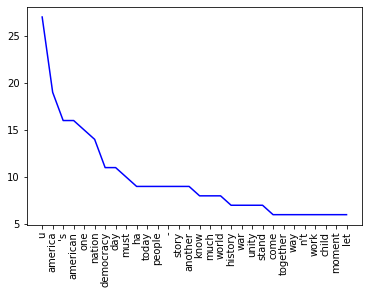

```python
from nltk import FreqDist
from matplotlib import pyplot as plt

# FreqDist() returns a list of tuples containing the lemma and the frequency
fd = FreqDist(lemmas_no_stopwords).most_common(30)
print(fd[:5])

# We need to switch from ('token', frequency) pairs
# into a list of tokens and a list of frequencies
xs = []
ys = []
for i in fd:
    xs.append(i[0])
    ys.append(i[1])

# Rotate the labels by 90 degrees
plt.xticks(rotation=90)

# Plot the labels and their frequencies in blue
plt.plot(xs, ys, 'b')

plt.show()
```

The top token, `u`, is derived from variations of `U(nited) S(tates)` in the source text; the tokenizer took it as an instance of `us`. Sometimes, tokenizers might not do very well in extracting good tokens. We will ignore it for now, but one might like to add an exception to the tokenization process (by adding an `if` statement in the `for` loop). Try doing this as an exercise!

We might also be interested in **tracking occurence of phrases** in time. Since the data we've been working on is only a single address, we will now download all past inaugural addresses to get a sense of this subject evolving in time.

```python
from nltk import download; download('inaugural')
from nltk.corpus import inaugural
```

We will compare the number of mentions of "america" and "people" and plot the results.

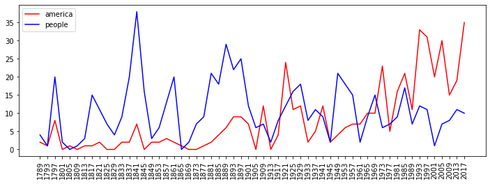

```python
def occur(words, word):
    # returns the number of occurences of a word in the list words
    occurences = 0
    for w in words:
        if w.startswith(word):
            occurences += 1
    return occurences

# create a list for speech names to be plotted on x-axis
# the .fileids() method returns a list with the file names ['1789-Washington.txt', '1793-Washington.txt', ...]
# we take first four characters which stand for the year of the speech
xs = []
for fileid in inaugural.fileids():
    xs.append(fileid[:4])

# create a list of all speeches
# the .words() method returns a list of the speech separated by whitespace
speeches = []
for fileid in inaugural.fileids():
    speeches.append(inaugural.words(fileid))

# tokenize the speeches
speech_tokens = []
for speech in speeches:
    inner = [] # list for a speech's tokens
    for word in speech:
        inner.append(lemmatizer.lemmatize(word).lower())
    speech_tokens.append(inner)

# create list for occurences of america based on tokens
ys1 = []
for speech_token in speech_tokens:
    ys1.append(occur(speech_token, "america"))

# create list for occurences of people based on tokens
ys2 = []
for speech_token in speech_tokens:
    ys2.append(occur(speech_token, "peopl"))

# plot both occurences as lines
fig, ax = plt.subplots(figsize=(12, 4))
plt.xticks(rotation=90)
am, = ax.plot(xs, ys1, "r", label="america")
pe, = ax.plot(xs, ys2, "b", label="people")
plt.legend([am, pe], ["america", "people"])

plt.show()
```

How does it compare to our data? The words America and People were used almost exactly as often in the Biden and Trump inauguration speeches.

```python
print(occur(lemmas_no_stopwords, "america"), "of america,",
      occur(lemmas_no_stopwords, "people"), "of people")
```

```
35 of america, 9 of people
```

# END OF PART 1

In the next part you will see

- Sentiment analysis
- Topic modelling

# Appendix

See below for more advanced material which is not central to this tutorial, but useful to be aware of. You will see how to

- List comprahensions
- Search for patterns in text with regular expressions
- Use the Wordnet lexical database e.g. to find synonyms

List comprahensions give us an easy way to construct lists.

```
[DO_SOMETHING(ITEM) for ITEM in COLLECTION if CONDITION(ITEM)]
```

```python
[i**2 for i in range(10)]
```

```
[0, 1, 4, 9, 16, 25, 36, 49, 64, 81]
```

This is identical (but much more compact) to

```python
tmp = []
for i in range(10):
    tmp.append(i**2)
tmp
```

```
[0, 1, 4, 9, 16, 25, 36, 49, 64, 81]
```

Let's try to add a condition that we only want to square even numbers

```python
[i**2 for i in range(10) if i % 2 == 0]
```

```
[0, 4, 16, 36, 64]
```

We can nest list comprahensions, for example we might want to get a 5 by 5 array of tuples

```python
[[(i, j) for j in range(5)] for i in range(5)]
```

```
[[(0, 0), (0, 1), (0, 2), (0, 3), (0, 4)],
 [(1, 0), (1, 1), (1, 2), (1, 3), (1, 4)],
 [(2, 0), (2, 1), (2, 2), (2, 3), (2, 4)],
 [(3, 0), (3, 1), (3, 2), (3, 3), (3, 4)],
 [(4, 0), (4, 1), (4, 2), (4, 3), (4, 4)]]
```

*Exercise*. Rewrite the `for` loops in this workshops as list comprahensions.

For example

```
tokens = []
for word in word_tokenize(data):
    tokens.append(word)
```

should become

```
tokens = [word for word in word_tokenize(data)]
```

[**Regular expressions**](https://en.wikipedia.org/wiki/Regular_expression), also known as regex, allow us to search strings using patters. It is a very expressive, but often slightly cryptic solution. You might know the `grep` function from R, it stands for "**g**lobal search for **r**egular **e**xpression and **p**rint matching lines"! It is a very robust tool for queries on well-structured text. A useful tool for developing regex patterns interactively is the [RegExr](https://regexr.com/).

We can now do a variety of very specific queries on our text. Regex is very useful for finding patterns (for example, mentions of company names in a large document) or validating input (for example, user input email address should allow `so-me.one@some.where` but disallow `wdiajdiawjdiwjd`). Regex is also a standard in many applications like word processing software or search engines.

```python
import re

some_string = "Is this LSE? Well, I hope this will help!"

# One or more lowercase letters followed by a single exclamation mark
print(re.findall("[a-z]+!", some_string))

# One or more uppercase letters followed by zero or more lowercase letters
print(re.findall("[A-Z]+[a-z]*", some_string))

# Letter `l` exactly twice followed by any character
print(re.findall("l{2}.", some_string))
```

```
['help!']
['Is', 'LSE', 'Well', 'I']
['ll,', 'll ']
```

[**WordNet**](https://wordnet.princeton.edu/), a powerful lexical database of English, is accessible to us from NLTK. It collects words into sets of synonyms called *synsets*. Everything is classified into a rigid linguistic structure, we can search through hyponyms and hypernyms, and much more. For example, the lemmanization we saw before is based precisely on this database. See [NLTK Wordnet manual](https://www.nltk.org/howto/wordnet.html) for more practical details.

```python
from nltk.corpus import wordnet as wn

def get_synonyms(word):
    synsets = wn.synsets(word)
    if not synsets:
        return {}
    return set.union(*[set(ss.lemma_names()) for ss in synsets])

get_synonyms("rather")
```

```
{'instead',
 'kind_of',
 'kinda',
 'preferably',
 'quite',
 'rather',
 'sooner',
 'sort_of'}
```